# Ejercicio 1.4.

Marta Piñol

19 de septiembre de 2017

La siguiente tabla contiene los mejores tiempos conseguidos en algunas pruebas de velocidad en atletismo en los Juegos Ol´impicos de Atlanta:

(com fer una taula)

| distancia | tiempo hombres | tiempo mujeres |
| --- | --- | --- |
| 100 | 9.84 | 10.94 |

Si tomamos como variable regresora o independiente la distancia (metros) y como variable respuesta o dependiente el tiempo (segundos):

## Apartado (a)

Calcular la recta de regresión simple con los datos de los hombres y dibujarla. Dibujar el gráfico de los residuos con la distancia y el gr´afico con las predicciones. Calcular la suma de cuadrados de los residuos y el $R^2$.

-> Si posem algo entre $ s’enten com a fórmula LATe

```r
dist <- c(100,200,400,800,1500,5000,10000,42192)
tiempoh <- c(9.84, 19.32, 43.19, 102.58, 215.78, 787.96, 1627.34, 7956.00)
tiempom <- c(10.94, 22.12, 48.25, 117.73, 240.83, 899.88, 1861.63, 8765.00)
summary(dist)
```

```
##    Min. 1st Qu.  Median    Mean 3rd Qu.    Max.
##     100     350    1150    7524    6250   42192
```

```r
summary(tiempoh)
```

```
##    Min. 1st Qu.  Median    Mean 3rd Qu.    Max.
##    9.84   37.22  159.18 1345.25  997.80 7956.00
```

La recta de regresión és:

```r
g <- lm(tiempoh ~ dist)
coef(g)
```

```
## (Intercept)        dist
## -78.2342453   0.1891926
```

La recta és $y = -78.23 + 0.19x$.

Gràfic dels residus:

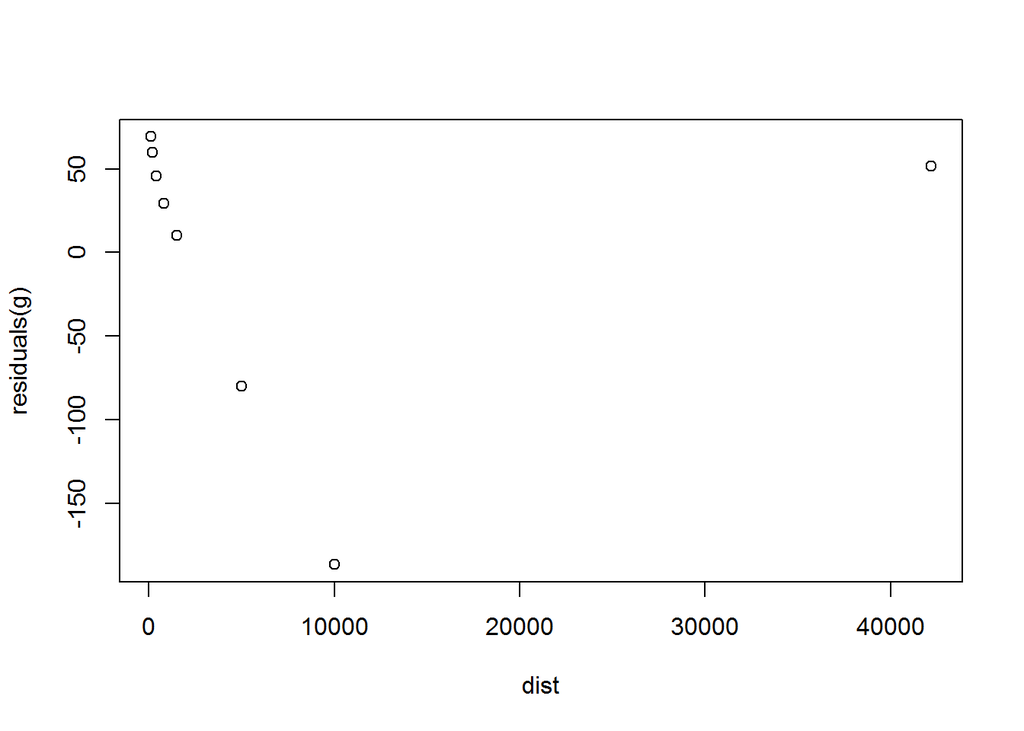

```r
plot(dist, residuals(g))
```

No sembla que els punts estiguin al atzar al voltant del 0. Tenim un punt molt llunyà al conjunt de les dades…No pinta bé.

Gràfic de les prediccions:

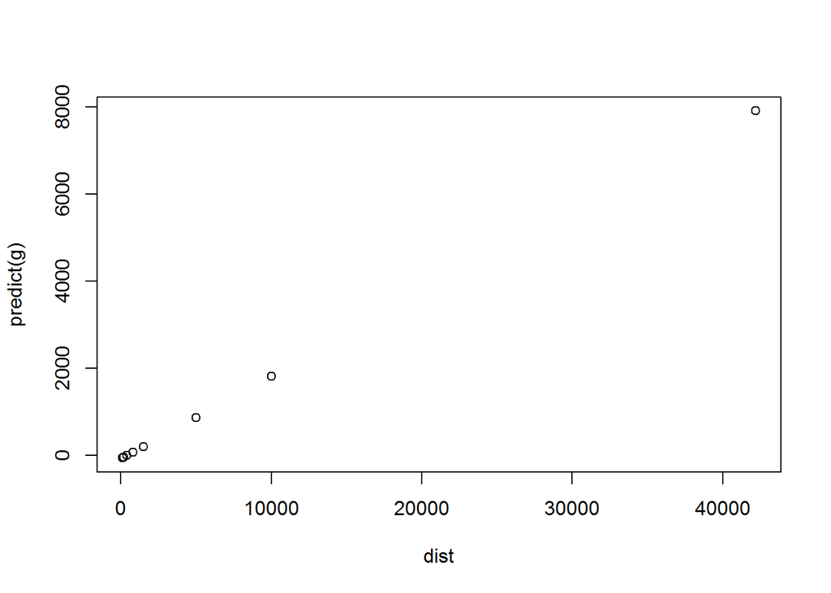

```r
plot(dist, predict(g))
```

Tenim un punt lluny que és un punt influyent (determina cap a on tira la recta). Situació que no hauria de passar.

La suma de quadrats dels residus és:

```r
sum(residuals(g)^2)
```

```
## [1] 55189
```

El coeficient de determinació $R^2$:

```r
ss <- summary(g)
ss$r.squared
```

```
## [1] 0.9989417
```

L’ajust entre la recta i els punts és molt bo. Això no té per que voler dir que el model sigui correcte.

## La recta amb logaritmes

La recta de regresión és:

```r
lg <- lm(log(tiempoh) ~ log(dist))
coef(lg)
```

```
## (Intercept)   log(dist)
##   -2.885964    1.118094
```

La recta és $y = -2-88 + 1.12x$.

Gràfic dels residus:

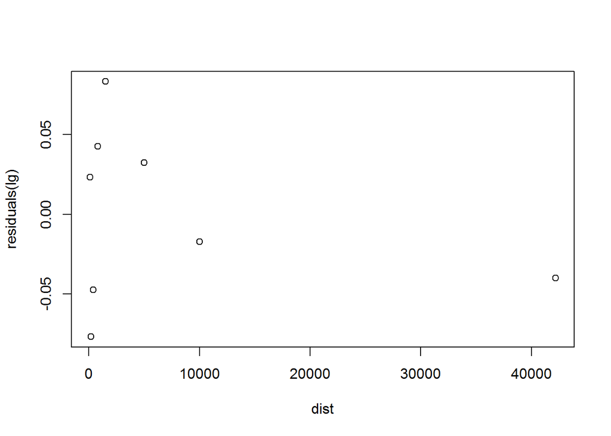

```r
plot(dist, residuals(lg))
```

Gràfic de les prediccions:

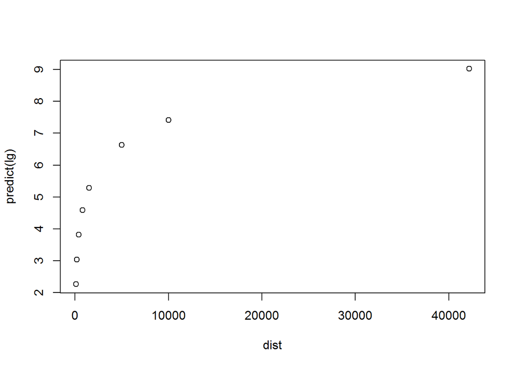

```r
plot(dist, predict(lg))
```

Tenim un punt lluny que és un punt influyent (determina cap a on tira la recta). Situació que no hauria de passar.

La suma de quadrats dels residus és:

```r
sum(residuals(lg)^2)
```

```
## [1] 0.02042962
```

El coeficient de determinació $R^2$:

```r
ss <- summary(lg)
ss$r.squared
```

```
## [1] 0.9994503
```